# SHARP: TCGA colon adenocarcinoma

ks

2025-05-17

## TCGA colon adenocarcinoma

We’re going to analyze colon adenocarcinoma data from the Cancer Genome Atlas (TCGA). Patient clinical information along with some tumor characteristics were downloaded from the R package: curatedTCGAData. The molecular data are gene expression and DNA methylation. The samples selected had the most complete information on the tumor variables MSI status and DNA methylation subtype.

The expression data were a count matrix from RNA sequencing and there was considerable variation in total counts (library size) across the samples. I normalized the counts by sample (library) using counts per million and removed genes that were not expressed in at least 10% of the samples. Then I log2-transformed the data to stabilize the variances of the genes. On the log2 scale, the variance of gene expression is approximately independent of the mean expression level. This is not true on the count scale.

I also filtered the DNA methylation data on variance, requiring variance greater than the median (0.003) and dropping the ~500 features with missing values. Often investigators will also remove features that have a SNP at the target CpG site or that are mapped in repetitive regions. I did not filter on those criteria.

Here are the variables in the data set:

```
## List of 5
##  $ covars:'data.frame':  163 obs. of  8 variables:
##   ..$ age                : int [1:163] 82 71 75 68 43 57 53 73 71 62 ...
##   ..$ purity             : num [1:163] 0.59 0.25 0.69 0.93 0.8 0.84 0.52 1 1 0.62 ...
##   ..$ MSI.H              : num [1:163] 1 0 1 0 0 0 0 0 1 0 ...
##   ..$ CIMP.H             : num [1:163] 1 0 1 0 0 0 0 0 1 0 ...
##   ..$ female             : num [1:163] 1 0 1 1 1 1 1 0 1 0 ...
##   ..$ MSI_status         : chr [1:163] "MSI-H" "MSS" "MSI-H" "MSS" ...
##   ..$ methylation_subtype: chr [1:163] "CIMP.H" "Cluster4" "CIMP.H" "Cluster3" ...
##   ..$ sex                : Factor w/ 2 levels "female","male": 1 2 1 1 1 1 1 2 1 2 ...
##  $ lcpmy : num [1:15957, 1:163] 2.06 1.17 4.21 7.9 3.24 ...
##   ..- attr(*, "dimnames")=List of 2
##   .. ..$ : chr [1:15957] "A1BG" "A1CF" "A2LD1" "A2M" ...
##   .. ..$ : chr [1:163] "TCGA-A6-2672" "TCGA-A6-2674" "TCGA-A6-2676" "TCGA-A6-2677" ...
##  $ dnam  : num [1:12283, 1:163] 0.788 0.933 0.335 0.618 0.73 ...
##   ..- attr(*, "dimnames")=List of 2
##   .. ..$ : chr [1:12283] "cg00000292" "cg00002426" "cg00003994" "cg00005847" ...
##   .. ..$ : chr [1:163] "TCGA-A6-2672" "TCGA-A6-2674" "TCGA-A6-2676" "TCGA-A6-2677" ...
##  $ fdnam :'data.frame':  12283 obs. of  5 variables:
##   ..$ Chr                                 : chr [1:12283] "16" "3" "7" "2" ...
##   ..$ Color_Channel                       : chr [1:12283] "Red" "Red" "Red" "Grn" ...
##   ..$ CPG_ISLAND..UCSC.                   : logi [1:12283] FALSE FALSE FALSE FALSE FALSE FALSE ...
##   ..$ ANY.POLYCOMB                        : chr [1:12283] "No" NA "Yes" "Yes" ...
##   ..$ Distance..bp..of.targeted.CpG.to.SNP: num [1:12283] 30.5 NA NA 12.5 NA 20.5 NA 46.5 NA NA ...
##  $ dnamid: chr [1:8672] "cg00000292" "cg00002426" "cg00003994" "cg00005847" ...
```

I limited the covariates to a few interesting variables:  
* age (=age_at_initial_pathologic_diagnosis)  
* sex (male/female)  
* MSI_status (MSI-H/MSI-L/MSS)  
* methylation_subtype (CIMP.H, CIMP.L, Cluster3, Cluster4)  
* purity (fraction tumor cells)

A variable that is important when studying tissue is the cell composition. Different cell types have different DNA methylation profiles and different genes expressed. Human tumors are a complex mixture of cells, and not all cells in the tumor are cancer cells. There are a number of methods now for estimating tumor purity. I downloaded an estimate obtained from the method: ABSOLUTE (PMID: 22544022) (purity).

Now we can summarize the clinical variables of primary interest by sex.

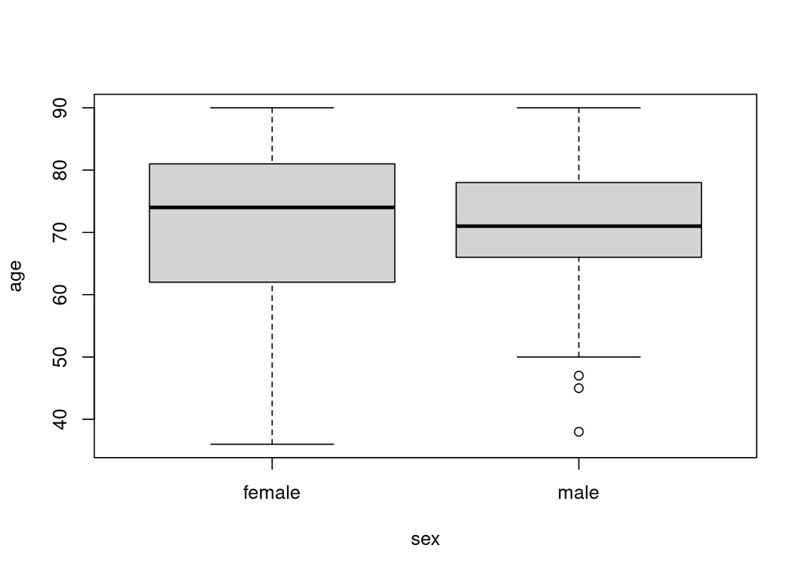

```r
with(coad$covars,
     boxplot(age~sex))
```

```r
msitab <- with(coad$covars,table(MSI_status,sex))
msitab
```

```
##           sex
## MSI_status female male
##      MSI-H     23    8
##      MSI-L     17   17
##      MSS       42   56
```

```r
prop.table(msitab,2)
```

```
##           sex
## MSI_status     female       male
##      MSI-H 0.28048780 0.09876543
##      MSI-L 0.20731707 0.20987654
##      MSS   0.51219512 0.69135802
```

We see a strong association with females having more MSI high tumors than males.

```r
cimptab <- with(coad$covars,table(methylation_subtype,sex))
cimptab
```

```
##                    sex
## methylation_subtype female male
##            CIMP.H       21   11
##            CIMP.L       17   21
##            Cluster3     22   24
##            Cluster4     22   24
```

```r
prop.table(cimptab,2)
```

```
##                    sex
## methylation_subtype    female      male
##            CIMP.H   0.2560976 0.1375000
##            CIMP.L   0.2073171 0.2625000
##            Cluster3 0.2682927 0.3000000
##            Cluster4 0.2682927 0.3000000
```

CIMP high tumors are also more common in females. In fact, there is a strong association between CIMP high and MSI high tumors.

```r
msicimp <- with(coad$covars,table(methylation_subtype,MSI_status))
prop.table(msicimp,2)
```

```
##                    MSI_status
## methylation_subtype      MSI-H      MSI-L        MSS
##            CIMP.H   0.77419355 0.05882353 0.06185567
##            CIMP.L   0.12903226 0.29411765 0.24742268
##            Cluster3 0.03225806 0.26470588 0.37113402
##            Cluster4 0.06451613 0.38235294 0.31958763
```

Let’s see whether tumor purity is associated with any of the variables we’ve studied so far.

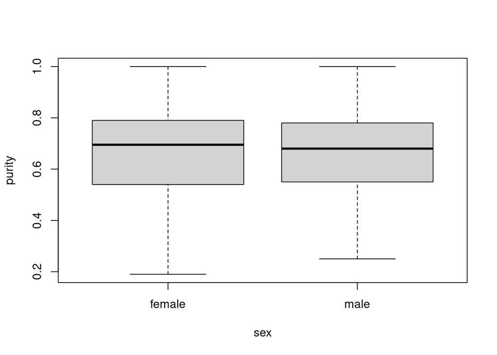

```r
with(coad$covars,boxplot(purity~sex))
```

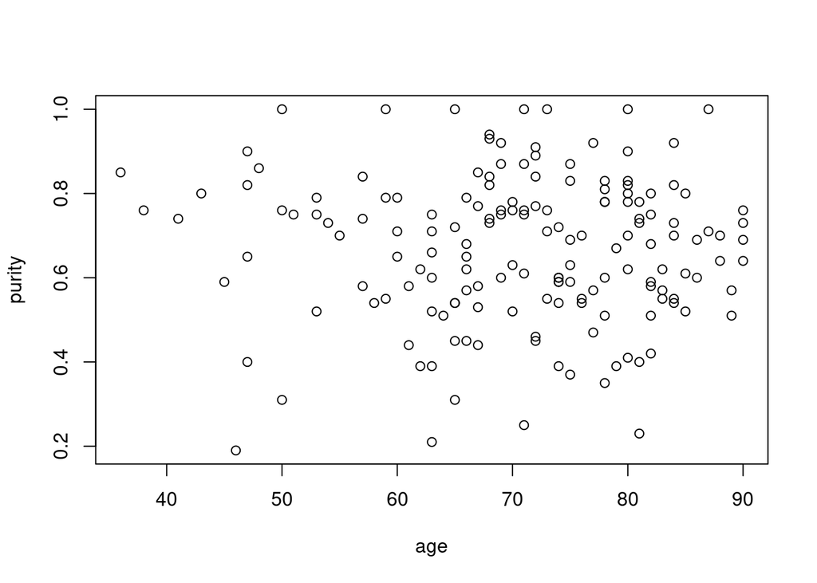

```r
with(coad$covars,plot(age,purity))
```

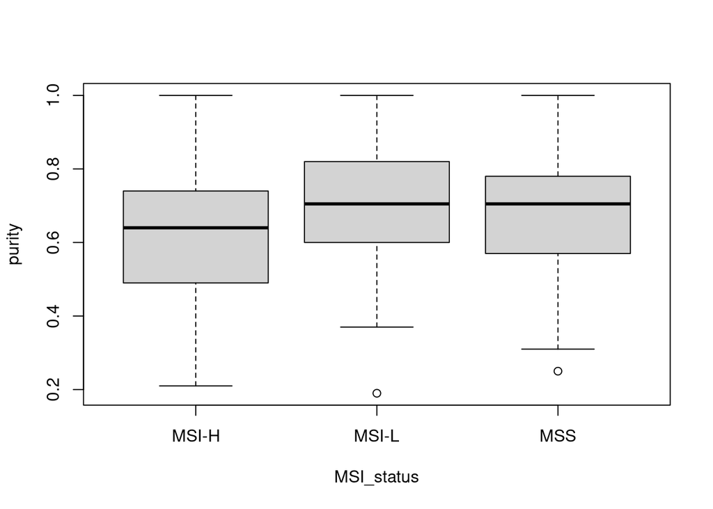

```r
with(coad$covars,boxplot(purity~MSI_status))
```

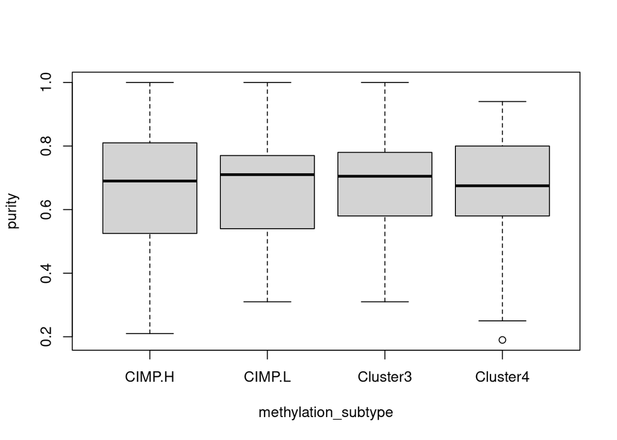

```r
with(coad$covars,boxplot(purity~methylation_subtype))
```

There doesn’t appear to be any association of tumor purity with the other variables of interest. We can show this in the correlation matrix.

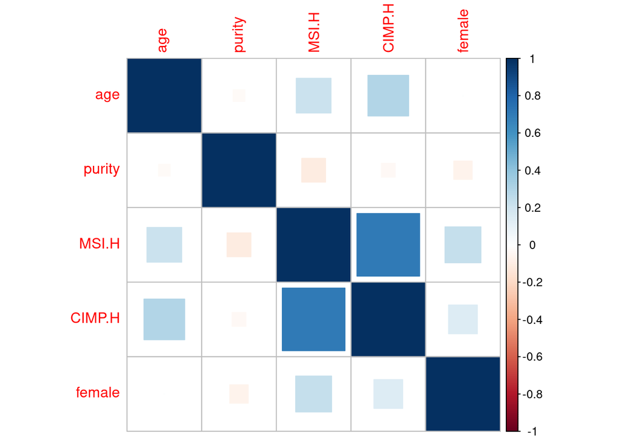

```r
cormat <- cor(coad$covars[,1:5],use="pairwise.complete.obs")
corrplot::corrplot(cormat, method="square")
```

Still, what is the effect of (lack of) tumor purity on the analysis of the gene expression and DNA methylation data?

## Gene Expression

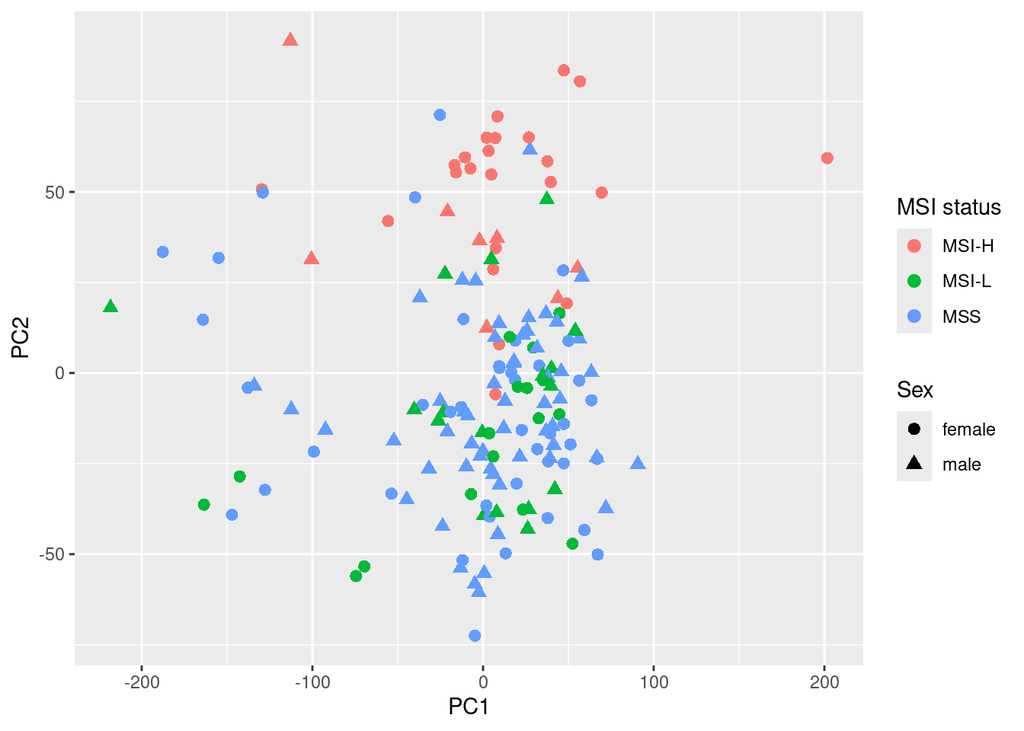

```r
# pick 500 most variable features
fmad  <- matrixStats::rowMads(coad$lcpmy)
rfmad <- rank(-fmad)
fidx <- which(rfmad <= 500)

# transpose the expression matrix
tE <- t(coad$lcpmy[fidx,])
tE <- t(coad$lcpmy)
sdztE <- scale(tE)
#pca
my.pcaE <- prcomp(sdztE,retx=TRUE)
epcs <- as.data.frame(my.pcaE$x)

ggplot(epcs,  aes(x=PC1, y=PC2, color = coad$covars$MSI_status , shape = coad$covars$sex)) + geom_point(size=2.5) +
  labs(color="MSI status",shape="Sex")
```

Let’s look at the correlation of the first 8 PCs with our covariates

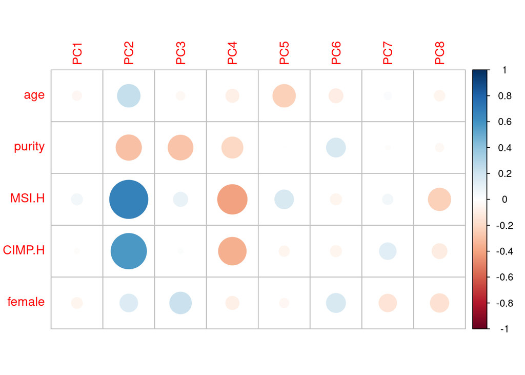

```r
pc1thru8 <- epcs[,1:8]
cormat <- cor(coad$covars[,1:5],pc1thru8,use="pairwise.complete.obs")
corrplot::corrplot(cormat)
```

How much of the gene expression variation do these PCs explain?

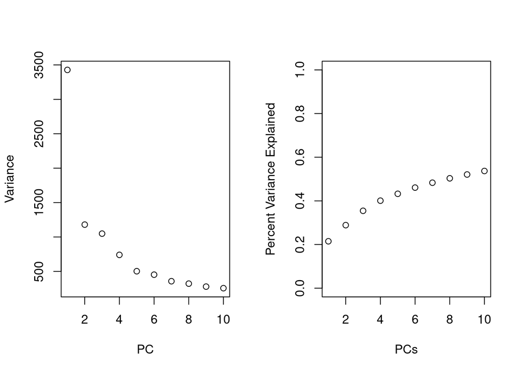

```r
pcvar <- my.pcaE$sdev^2   #These are variances of PCs
cumvar <- cumsum(pcvar)
pctvar <- cumvar/max(cumvar)
par(mfrow=c(1,2))
plot(1:10,pcvar[1:10],xlab="PC",ylab="Variance")
plot(1:10,pctvar[1:10],xlab="PCs",ylab="Percent Variance Explained",ylim=c(0,1))
```

10 PCs explain ~50% of the variance in the gene expression data set.

## DNA methylation

Now let’s see what happens when we do a similar analysis with DNA methylation data.

The DNAm values, called Beta values by Illumina, are proportions, bounded by 0 and 1. These should be transformed prior to analysis to be more normally distributed. A logit-like transformation works well here, M values = log2 (beta/1-beta).

```r
  mvals <- function(beta){  log2(beta/(1-beta)) }
  mcoad <- mvals(coad$dnam)
```

Let’s look at a pca plot of these. Again, I will analyze the 500 most variable features only.

EXTRA CREDIT: Try re-doing this plot without the filtering to see how it affects the relationships with the biological variables.

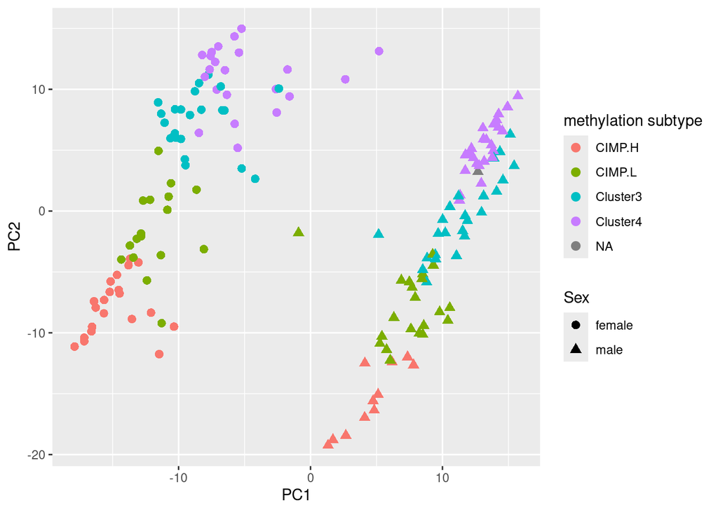

```r
# pick 500 most variable features
fmad  <- matrixStats::rowMads(mcoad)
rfmad <- rank(-fmad)
fidx <- which(rfmad <= 500)

# transpose the DNAm matrix
tM <- t(mcoad[fidx,])
#tM <- t(mcoad)  #un-comment this line to analyze all variables without filtering
sdztM <- scale(tM,center=TRUE,scale=
                 matrixStats::colMads(tM))
my.mpca <- prcomp(sdztM,retx=TRUE)
mpcs <- as.data.frame(my.mpca$x)

ggplot(mpcs,  aes(x=PC1, y=PC2, color = coad$covars$methylation_subtype , shape = coad$covars$sex)) + geom_point(size=2.5) +
  labs(color="methylation subtype",shape="Sex")
```

PC1 and PC2 can separate patients by sex perfectly.

How much of the DNAm variation do these PCs explain?

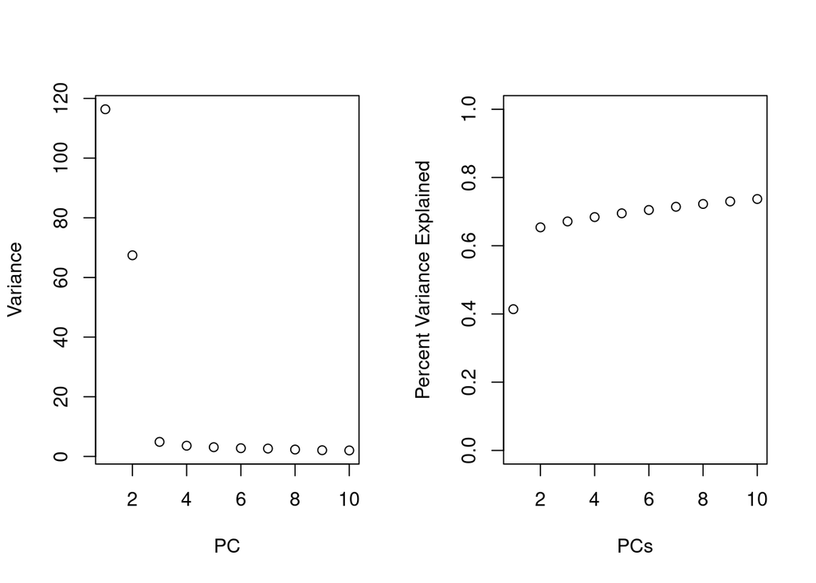

```r
pcvar <- my.mpca$sdev^2   #These are variances of PCs
cumvar <- cumsum(pcvar)
pctvar <- cumvar/max(cumvar)
par(mfrow=c(1,2))
plot(1:10,pcvar[1:10],xlab="PC",ylab="Variance")
plot(1:10,pctvar[1:10],xlab="PCs",ylab="Percent Variance Explained",ylim=c(0,1))
```

PCs 1 & 2 explain over 60% of the variance measured by the top 500 variable features.

Let’s check the distribution of CpGs by chromosome.

```r
table(coad$fdnam$Chr)
```

```
##
##    1   10   11   12   13   14   15   16   17   18   19    2   20   21   22    3
## 1185  435  805  618  205  314  349  466  695  195  882  711  407  156  264  621
##    4    5    6    7    8    9    X    Y
##  479  519  641  569  393  436  931    7
```

X chromosome methylation is different in males and females (X chromosome inactivation). This is something you will always have to look out for when analyzing males and females together.

```r
sum(is.element(coad$fdnam$Chr,c("X","Y"))/length(coad$fdnam$Chr))
```

```
## [1] 0.07636571
```

Just $7.6\%$ of the features are on sex chromosomes but when we filter on variance, we’re selecting these into our analysis set and they will have a large impact on the cluster results. Let’s drop the features on the sex chromosomes before performing our dimension reduction techniques.

```r
mdnam <- mcoad[
          !is.element(coad$fdnam$Chr,c("X","Y")),]
fdnam <- coad$fdnam[!is.element(coad$fdnam$Chr,c("X","Y")),]
dim(mdnam)
```

```
## [1] 11345   163
```

```r
nrow(fdnam)
```

```
## [1] 11345
```

Now what do we get from a PCA?

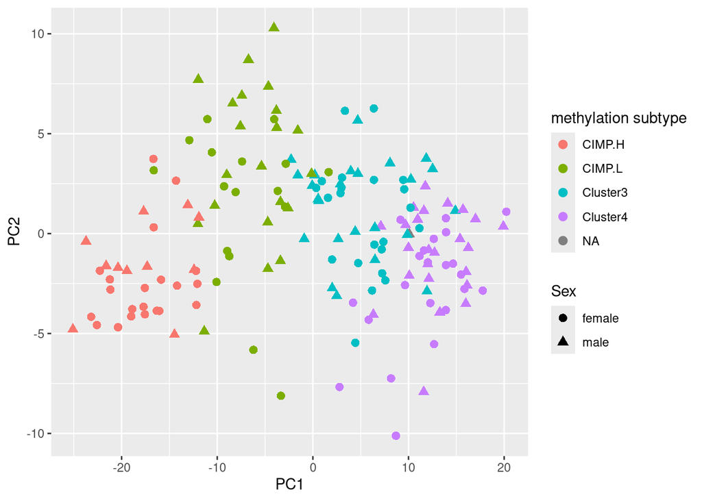

```r
# pick 500 most variable features
fmad  <- matrixStats::rowMads(mdnam)
rfmad <- rank(-fmad)
fidx <- which(rfmad <= 500)

# transpose the dnam matrix
tM <- t(mdnam[fidx,])
sdztM <- scale(tM,center=TRUE,scale=
                 matrixStats::colMads(tM))
my.mpca <- prcomp(sdztM,retx=TRUE)
mpca <- as.data.frame(my.mpca$x)

ggplot(mpca,  aes(x=PC1, y=PC2, color = coad$covars$methylation_subtype, shape = coad$covars$sex)) + geom_point(size=2.5) +
  labs(color="methylation subtype",shape="Sex")
```

The separation by sex has disappeared now. How do the top PCs correlate with the covariates?

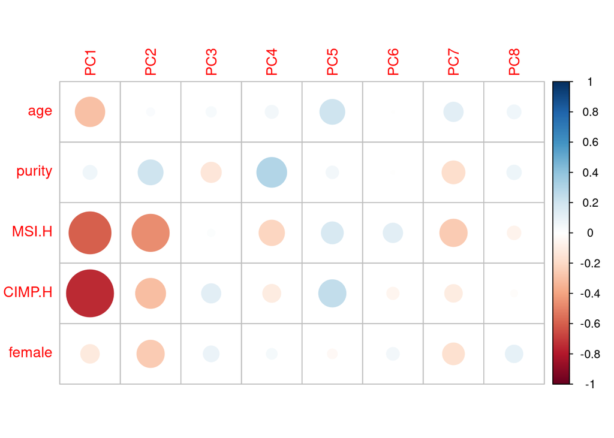

```r
covmat  <- cor(coad$covars[,1:5],mpca[,1:8],use="pairwise.complete.obs")
corrplot::corrplot(covmat)
```

PC1 is highly correlated with both CIMP-H and MSI-H. This resembles the correlation matrix with the PCs from the gene expression data. Somewhat troubling is the correlation with purity that is seen in multiple PCs.

How much of the DNAm variation do these PCs explain?

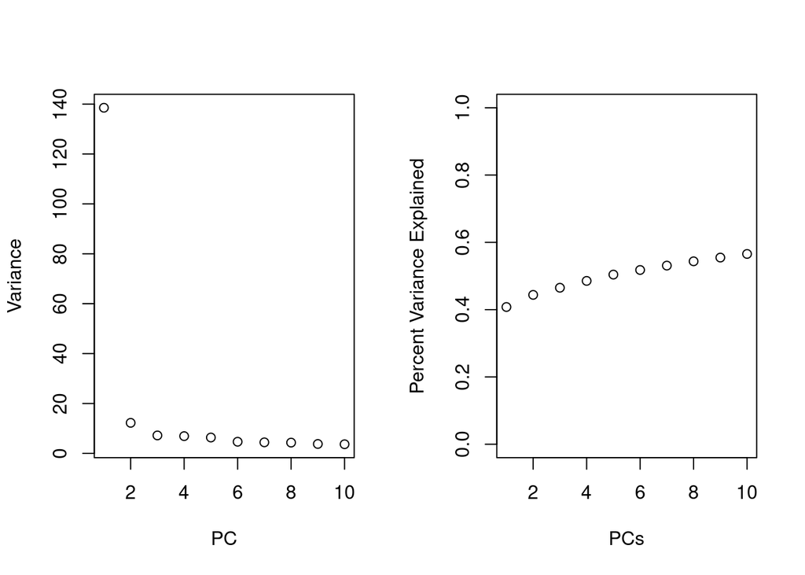

```r
pcvar <- my.mpca$sdev^2   #These are variances of PCs
cumvar <- cumsum(pcvar)
pctvar <- cumvar/max(cumvar)
par(mfrow=c(1,2))
plot(1:10,pcvar[1:10],xlab="PC",ylab="Variance")
plot(1:10,pctvar[1:10],xlab="PCs",ylab="Percent Variance Explained",ylim=c(0,1))
```

## Sparse CCA

With high-dimensional data, the standard canonical correlation analysis won’t work. There are several new methods that have been proposed for estimating canonical correlations in this setting and we’ll use the sparse CCA propsed by Witten et al. (2009) and available in the PMA package. This CCA has feature selection built in, but we need to pick the penalty parameter. We will run a function to search for the best penalty parameters. The smaller the penalty parameter, the fewer variables are fit in the model. Since we only have 163 subjects and we have nearly 100 times as many variables, I’m going to limit my search to low values of the penalty parameter.

First, we standardize the columns of the DNA methylation and gene expression matrices.

```r
  X <- scale(t(mdnam))
  Z <- scale(t(coad$lcpmy))
```

This is going to take a little time to run because it will run 7 permutations over a grid of length 8. I should run more permutations, but this will be sufficient for illustration.

```r
set.seed(47)
perm.out <- CCA.permute(X,Z,typex="standard",
                        typez="standard",
                        penaltyxs=seq(.01,.2,len=8),
                        penaltyzs=seq(.01,.2,len=8),
                        nperms=7)
```

```
##
##  Permutation  1  out of  7  12345678
##  Permutation  2  out of  7  12345678
##  Permutation  3  out of  7  12345678
##  Permutation  4  out of  7  12345678
##  Permutation  5  out of  7  12345678
##  Permutation  6  out of  7  12345678
##  Permutation  7  out of  7  12345678
```

```r
print(perm.out)
```

```
## Call: CCA.permute(x = X, z = Z, typex = "standard", typez = "standard",
##     penaltyxs = seq(0.01, 0.2, len = 8), penaltyzs = seq(0.01,
##         0.2, len = 8), nperms = 7)
##
## Type of x:  standard
## Type of z:  standard
##   X Penalty Z Penalty Z-Stat P-Value  Cors Cors Perm FT(Cors) FT(Cors Perm)
## 1     0.010     0.010  5.539       0 0.739     0.435    0.948         0.467
## 2     0.037     0.037 11.058       0 0.928     0.553    1.645         0.623
## 3     0.064     0.064 10.785       0 0.930     0.530    1.656         0.592
## 4     0.091     0.091  9.310       0 0.914     0.515    1.552         0.571
## 5     0.119     0.119  5.849       0 0.837     0.505    1.211         0.557
## 6     0.146     0.146  5.661       0 0.833     0.491    1.196         0.539
## 7     0.173     0.173  5.810       0 0.832     0.483    1.196         0.528
## 8     0.200     0.200  6.147       0 0.837     0.475    1.210         0.518
##   # U's Non-Zero # Vs Non-Zero
## 1              2             4
## 2             27            35
## 3             71           106
## 4            153           210
## 5            250           337
## 6            352           518
## 7            487           714
## 8            648           965
## Best L1 bound for x:  0.03714286
## Best L1 bound for z:  0.03714286
```

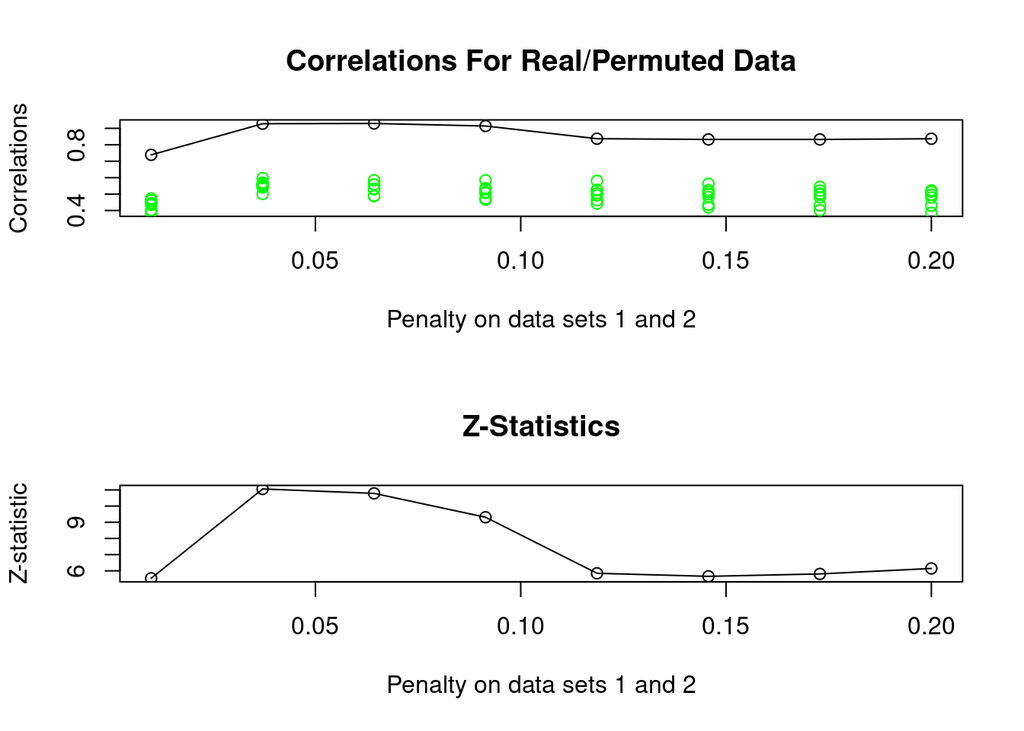

```r
plot(perm.out)
```

Now let’s fit CCA using the best penalty parameter, and ask for the top 3 canonical variables.

```r
out <- CCA(X,Z,typex="standard",typez="standard",K=3,
           penaltyx=perm.out$bestpenaltyx,
           penaltyz=perm.out$bestpenaltyz, v=perm.out$v.init)
```

```
## 123456789101112131415
## 123456789101112131415
## 1234567891011121314
```

```r
print(out)
```

```
## Call: CCA(x = X, z = Z, typex = "standard", typez = "standard", penaltyx = perm.out$bestpenaltyx,
##     penaltyz = perm.out$bestpenaltyz, K = 3, v = perm.out$v.init)
##
##
## Num non-zeros u's:  28 26 21
## Num non-zeros v's:  39 37 34
## Type of x:  standard
## Type of z:  standard
## Penalty for x: L1 bound is  0.03714286
## Penalty for z: L1 bound is  0.03714286
## Cor(Xu,Zv):  0.9163066 0.8676257 0.8322956
```

Num non-zero u’s gives the number of DNA methylation features selected in the 1st, 2nd, and 3rd canonical variables. Num non-zero v’s gives the number of gene expression features selected in the 1st, 2nd, and 3rd canonical variables. Cor(Xu,Zv) are the correlations between the first three pairs of canonical variables.

Let’s check that we can compute the same correlations from our data.

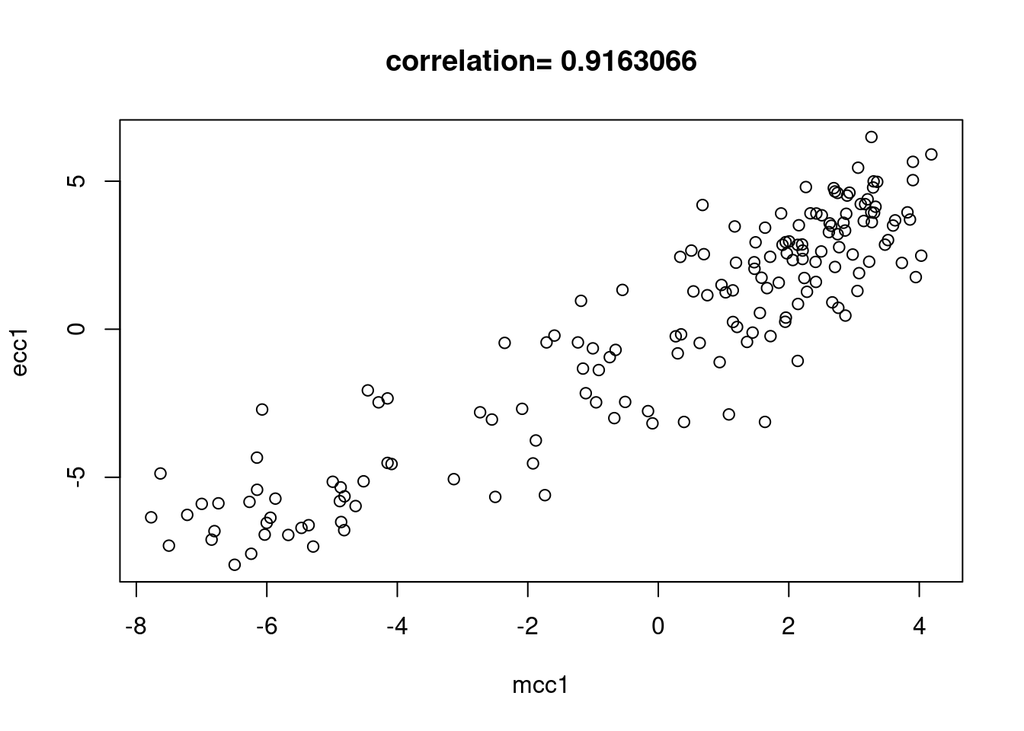

```r
mcc1<- X%*%out$u[,1]
ecc1<- Z%*%out$v[,1]
plot(mcc1,ecc1,main=paste("correlation=",round(cor(mcc1,ecc1),7)))
```

```r
mcc2<- X%*%out$u[,2]
ecc2<- Z%*%out$v[,2]

mcc3<- X%*%out$u[,3]
ecc3<- Z%*%out$v[,3]
ccvs <- cbind.data.frame(mcc1,ecc1,mcc2,ecc2,mcc3,ecc3)
```

Now let’s see if the canonical variables correlate with the PCs.

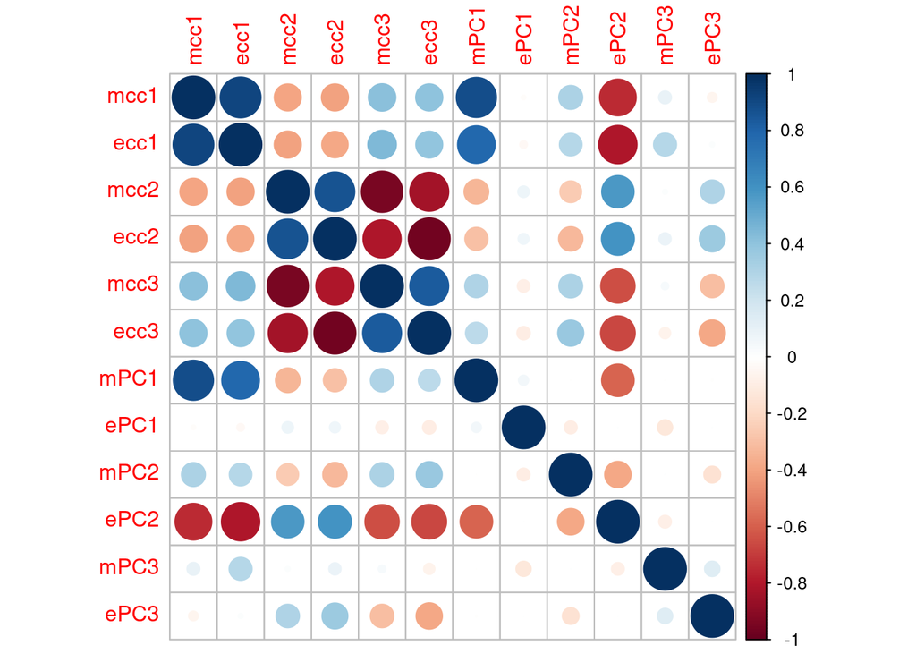

```r
pcs  <- cbind.data.frame(mPC1=mpca[,1],
                         ePC1=epcs[,1],
                         mPC2=mpca[,2],
                         ePC2=epcs[,2],
                         mPC3=mpca[,3],
                         ePC3=epcs[,3]
                         )
svs <- cbind.data.frame(ccvs,pcs)

corrplot::corrplot(cor(svs))
```

One thing to realize is that these canonical variables are not independent of one another like they were in low-dimensional space, or like the PCs.

Do they correlate with our clinical variables? (Age, sex, MSI status, methylation subtype.)

```r
cormat <- cor(coad$covars[,1:5],ccvs,use="pairwise.complete.obs")
round(cormat,2)
```

```
##         mcc1  ecc1  mcc2  ecc2  mcc3  ecc3
## age    -0.26 -0.28  0.09  0.11 -0.08 -0.11
## purity  0.11  0.11 -0.57 -0.43  0.58  0.46
## MSI.H  -0.77 -0.74  0.39  0.47 -0.41 -0.46
## CIMP.H -0.80 -0.68  0.29  0.31 -0.30 -0.31
## female -0.20 -0.14  0.01  0.09 -0.02 -0.10
```

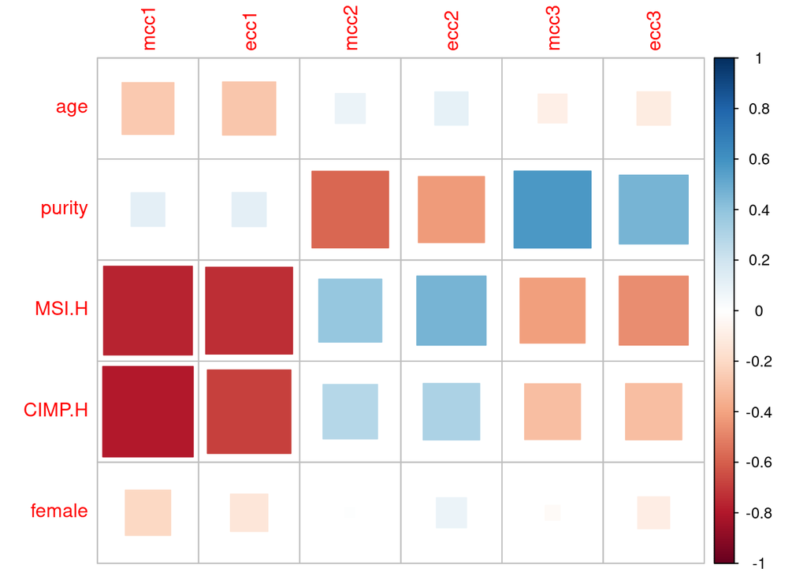

```r
corrplot::corrplot(cormat,method="square")
```

The second pair of canonical variables are now much more correlated with tumor purity than they were from the PC analysis.

Let’s recall what we saw with the PCs from separate analyses of the two data sets.

```r
cormat <- cor(coad$covars[,1:5],pcs,use="pairwise.complete.obs")
round(cormat,2)
```

```
##         mPC1  ePC1  mPC2  ePC2  mPC3  ePC3
## age    -0.29 -0.04  0.02  0.24  0.04 -0.04
## purity  0.07  0.00  0.21 -0.30 -0.14 -0.29
## MSI.H  -0.59  0.06 -0.46  0.67  0.02  0.10
## CIMP.H -0.74 -0.01 -0.30  0.58  0.12  0.01
## female -0.12 -0.06 -0.25  0.15  0.08  0.22
```

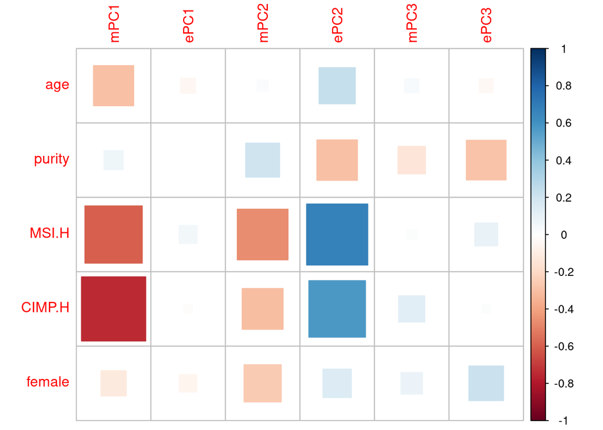

```r
corrplot::corrplot(cormat,method="square")
```

The correlation with tumor purity was less noticeable with the PCs of individual data types, but when we analyze the data jointly with CCA, this signal gets accentuated.

This shows that canonical correlation can prioritize signals shared from individual data types. Would we have found this if we had done a PCA of the concatenated data?

## PCA concatenated data

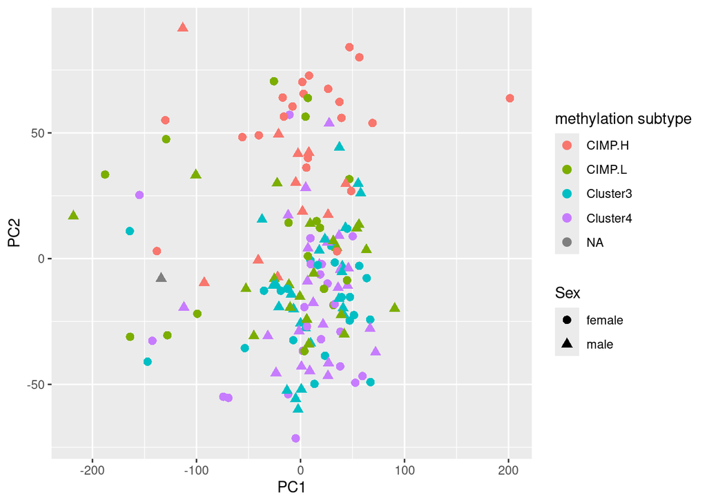

```r
my.cpca <- prcomp(cbind(sdztM,sdztE),retx=TRUE)
combpca <- as.data.frame(my.cpca$x)

ggplot(combpca,  aes(x=PC1, y=PC2, color = coad$covars$methylation_subtype, shape = coad$covars$sex)) + geom_point(size=2.5) +
  labs(color="methylation subtype",shape="Sex")
```

```r
cormat <- cor(coad$covars[,1:5],combpca[,1:5],use="pairwise.complete.obs")
round(cormat,2)
```

```
##          PC1   PC2   PC3   PC4   PC5
## age    -0.04  0.25 -0.04 -0.08 -0.23
## purity  0.00 -0.28 -0.28 -0.23  0.01
## MSI.H   0.06  0.71  0.09 -0.33  0.20
## CIMP.H -0.02  0.63  0.01 -0.32 -0.03
## female -0.06  0.15  0.22 -0.07 -0.02
```

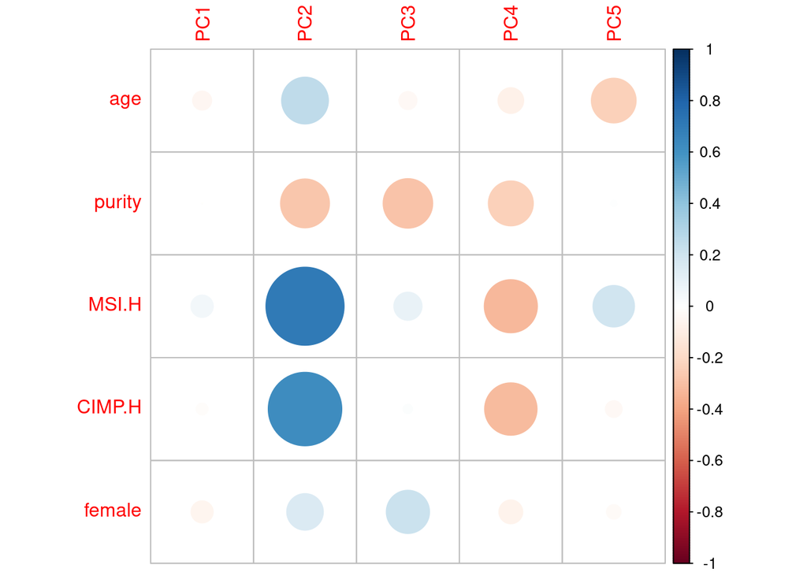

```r
corrplot::corrplot(cormat)
```

Results we found:  
1. A PCA of a subset of the data may find a different cluster result than PCA of the full data set. (e.g., DNA methylation finding clusters by sex)  
2. Signals shared by different data types might be better prioritized by canonical correlation variables than a PCA of the concatenated data set. (e.g., tumor purity). However, we did have a different feature selection when running the CCA.